# VCM Data Exploration

Barry von Tobel

11/21/2022

**Objective:**

Explore different metrics that can be used in gauging the quality of the space catalog.

**Discussion:**

There are many ways to understand a system’s behavior using statistical analysis of the generated output data. This exercise looks at the variances and aging of the individual Resident Space Objects (RSOs) derived from its latest state vector and positional variance.

Data is extracted from a set of the approximately 28,000 files Vector Covariance Messages (VCM) that are currently published by space-track.org three times a day. The downloaded VCM data is then unzipped to a folder where the ~28K files are extracted.

The VCMs’ extracted and calculated values are saved as a data frame in the Statistics Package R, where the analysis occurred. the Table entitled “Extracted VCM Data” shows the first few rows of the data frame.

## Extracted VCM Data - Top of ~28,000 rows

| Year | Day | SATNO | X | Y | Z | SD_U | SD_V | SD_W | tmp | VAR_U | VAR_V | VAR_W | Days | VOL_SD | VOL_VAR | Height |
| --- | --- | --- | --- | --- | --- | --- | --- | --- | --- | --- | --- | --- | --- | --- | --- | --- |
| 2022 | 271 | 11 | -8119.50 | -617.52 | 1442.82 | 0.01 | 0.04 | 0.01 | NA | 0 | 0 | 0 | 271 | 9385.34 | 0.02 | 1901.79 |
| 2022 | 269 | 12 | 7789.46 | -3142.18 | 1425.38 | 0.01 | 0.04 | 0.01 | NA | 0 | 0 | 0 | 269 | 9234.69 | 0.02 | 2151.43 |
| 2022 | 269 | 16 | 855.20 | 7015.32 | 922.24 | 0.01 | 0.02 | 0.01 | NA | 0 | 0 | 0 | 269 | 3809.89 | 0.00 | 759.18 |
| 2022 | 269 | 20 | -3029.77 | 6120.07 | 1320.85 | 0.00 | 0.01 | 0.01 | NA | 0 | 0 | 0 | 269 | 2306.82 | 0.00 | 587.53 |
| 2022 | 271 | 22 | 317.93 | -4877.97 | 4936.43 | 0.00 | 0.01 | 0.00 | NA | 0 | 0 | 0 | 271 | 865.34 | 0.00 | 579.23 |
| 2022 | 270 | 29 | -1206.75 | 4964.19 | 4807.63 | 0.01 | 0.02 | 0.01 | NA | 0 | 0 | 0 | 270 | 7726.94 | 0.01 | 647.17 |

==========================================================================================================

# Variance Volume

The Variance Volume is the volume of a 3D ellipsoid, that shows the uncertainty of the data that shows how varied the location can be withing hte ellipsoid. the volume is caculated from the variance of the u,v,w state vector’s SIGMA’s, which is believed to be the standard deviation of the values. The variance is the square of the SIGMA. The smaller the value, then the tighter the variance. The volume, in cubic meters, is then caculated - (4/3)*pi*VAR_U * VAR_V * VAR_W

The smaller the volume, the tighter the Variance, therefor the better probabliy of its location is better. Accompaning a graph is a table of summary statistics, a range of altitudes for this graph, and the graph’s plotting limits. Various heights can be analyzed, and a value such as the Mean can support a quality metric.

#### Orbital Band; 600 < Height < 700 Kilometers

X..df_uvw2.VOL_VAR

nobs

1.828000e+03

NAs

0.000000e+00

Minimum

0.000000e+00

Maximum

9.065821e+08

1. Quartile

1.000000e-02

3. Quartile

8.977000e+01

Mean

1.488906e+06

Median

7.900000e-01

Sum

2.721720e+09

SE Mean

7.303657e+05

LCL Mean

5.646637e+04

UCL Mean

2.921345e+06

Variance

9.751173e+14

Stdev

3.122687e+07

Skewness

2.617000e+01

Kurtosis

7.127700e+02

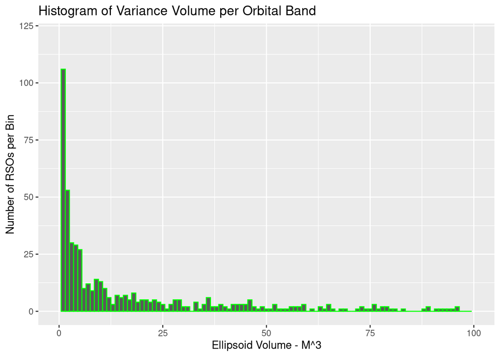

==========================================================================================================

# RSO Height

The Height is the altitude of the RSO assuming a circuar orbit who’s period is at the epoch of the VCM. This estimation is usually adequate for saying what orbital band the RSO is in. The height is calculated by the absolute value of the state vector minus the average earth radius in Kilometers - ((X ^2 + Y^2 + Z<sup>2)</sup>0.5) - 6368

#### Orbital Band; 600 < Height < 700 Kilometers

X..df_uvw2.Height

nobs

1850.00

NAs

0.00

Minimum

600.01

Maximum

699.99

1. Quartile

626.63

3. Quartile

677.75

Mean

651.61

Median

652.24

Sum

1205480.85

SE Mean

0.68

LCL Mean

650.27

UCL Mean

652.95

Variance

859.04

Stdev

29.31

Skewness

-0.06

Kurtosis

-1.21

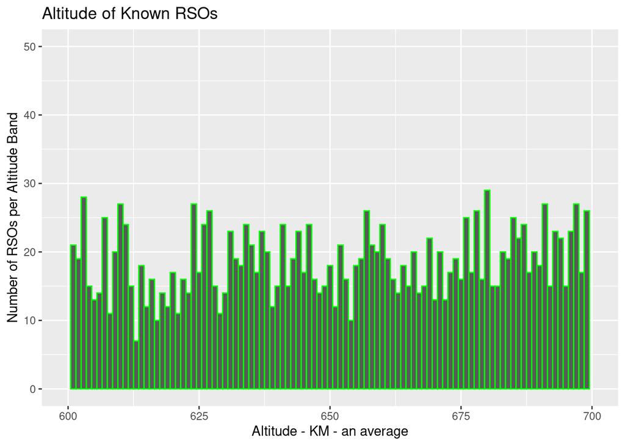

==========================================================================================================

# VCM Created Date

The aging is simply the creation date of the VCM, labeled EPOCH TIME (UTC). and is caculated by (2022 - Year) * 365 + Day)

#### xlim = 1 - 300, ylim = 0 - 100

#### Orbital Band; 600 < Height < 700 Kilometers

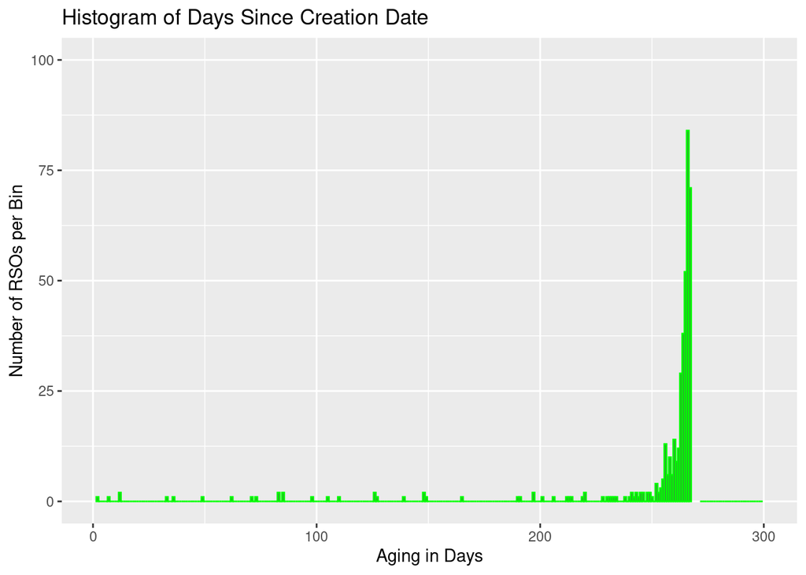

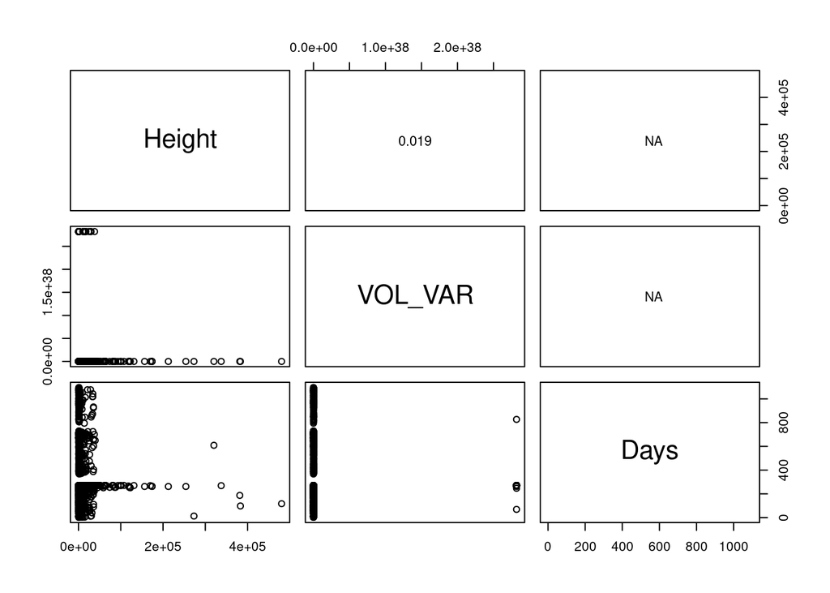